# Homework2

Toygar Emre

04 12 2020

```r
#Upload libraries and read datas
suppressMessages(library(tidyverse))
suppressMessages(library(plot3D))
suppressMessages(library(rgl))

X.Train<-read.table(file="uWaveGestureLibrary_X_TRAIN") %>% as_tibble()
Y.Train<-read.table(file="uWaveGestureLibrary_Y_TRAIN") %>% as_tibble()
Z.Train<-read.table(file="uWaveGestureLibrary_Z_TRAIN") %>% as_tibble()
```

QUESTION PART A

```r
sort(unique(X.Train$V1)) #Find unique classes
```

```
## [1] 1 2 3 4 5 6 7 8
```

Given class no, first row number(instance) for the class will be chosen as a sample.

```r
Random.Instance<-function(class.no){
  row.no<-first(which(X.Train$V1==class.no))
  Gesture<-as.data.frame(cbind(t(X.Train[row.no,]),t(Y.Train[row.no,]),t(Z.Train[row.no,]))) #For 3D purpose we bind columns
  colnames(Gesture)<-c("X","Y","Z")
  Gesture<-Gesture[-1,]#First row is class info. We do not need it
  rownames(Gesture)<-NULL
  Gesture.v<-as_tibble(apply(Gesture,2,cumsum))#Acceleration to velocity transformation

  return(Gesture.v)
}
par(mar=c(1,1,1,1))
```

1st Class

```r
res<-Random.Instance(1)
res %>% head
```

```
## # A tibble: 6 x 3
##        X      Y      Z
##    <dbl>  <dbl>  <dbl>
## 1 -0.791  -1.96 -0.249
## 2 -1.58   -3.92 -0.498
## 3 -2.38   -5.88 -0.750
## 4 -3.19   -7.82 -1.01
## 5 -4.04   -9.74 -1.29
## 6 -4.94  -11.6  -1.60
```

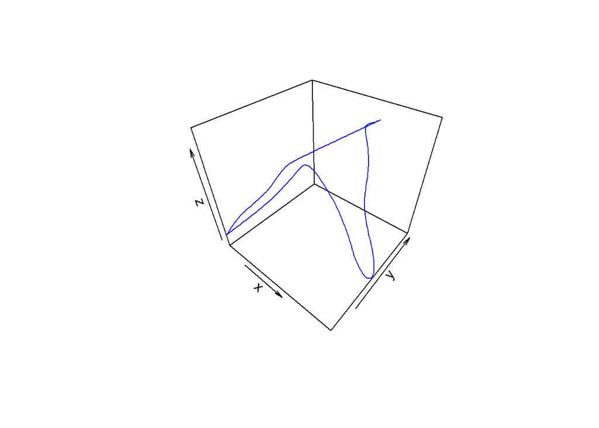

```r
plot3D::scatter3D(x = res$X,y = res$Y,z = res$Z,col = "blue",type="l",xlab = "x",ylab = "y",zlab = "z")
```

```r
#With below one new window will be opened and you can check 3D object with rotations.
#However for homework we will use the above one
#rgl::plot3d(x = res$X,y = res$Y,z = res$Z,type = "l" ,col = "blue",xlab = "x",ylab = "y",zlab = "z")
```

2nd Class

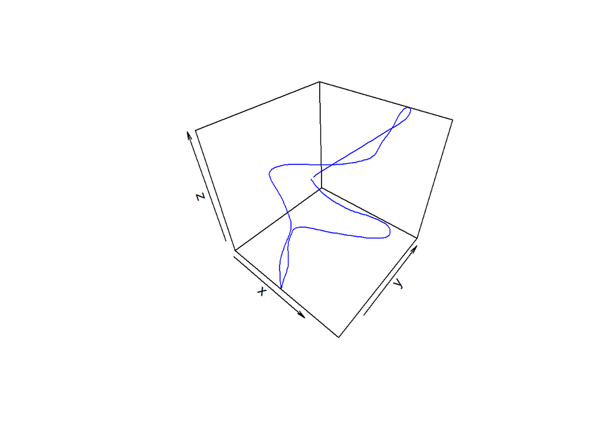

```r
res<-Random.Instance(2)
plot3D::scatter3D(x = res$X,y = res$Y,z = res$Z,col = "blue",type="l",xlab = "x",ylab = "y",zlab = "z")
```

3rd Class

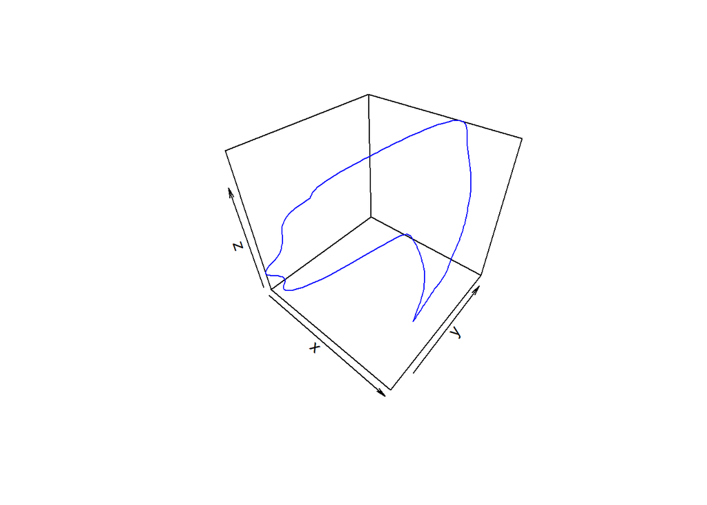

```r
res<-Random.Instance(3)
plot3D::scatter3D(x = res$X,y = res$Y,z = res$Z,col = "blue",type="l",xlab = "x",ylab = "y",zlab = "z")
```

4th Class

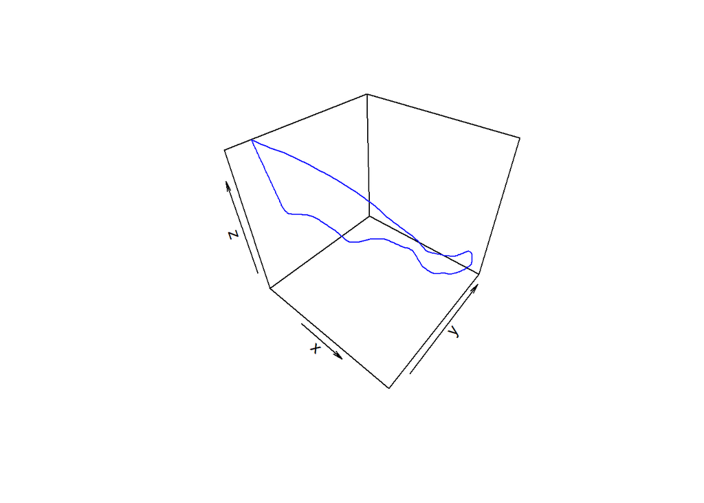

```r
res<-Random.Instance(4)
plot3D::scatter3D(x = res$X,y = res$Y,z = res$Z,col = "blue",type="l",xlab = "x",ylab = "y",zlab = "z")
```

5th Class

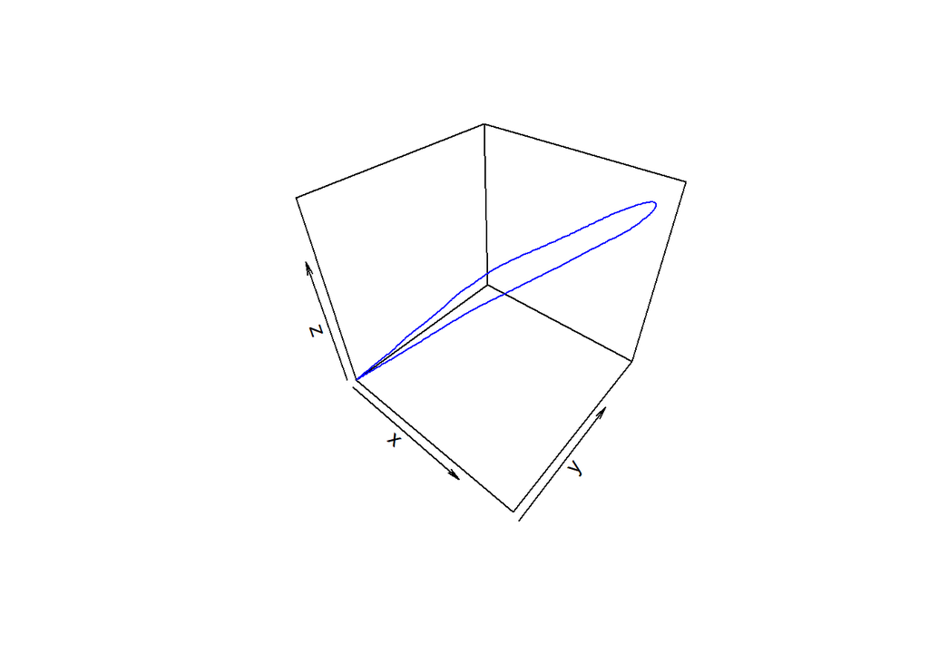

```r
res<-Random.Instance(5)
plot3D::scatter3D(x = res$X,y = res$Y,z = res$Z,col = "blue",type="l",xlab = "x",ylab = "y",zlab = "z")
```

6th Class

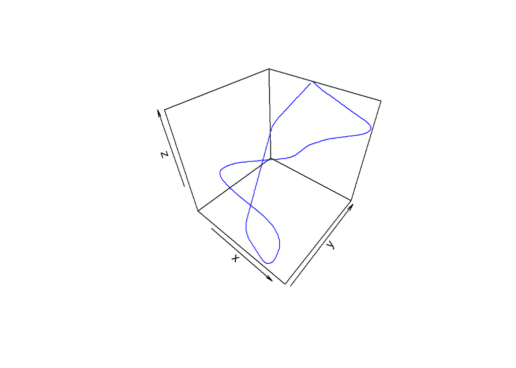

```r
res<-Random.Instance(6)
plot3D::scatter3D(x = res$X,y = res$Y,z = res$Z,col = "blue",type="l",xlab = "x",ylab = "y",zlab = "z")
```

7th Class

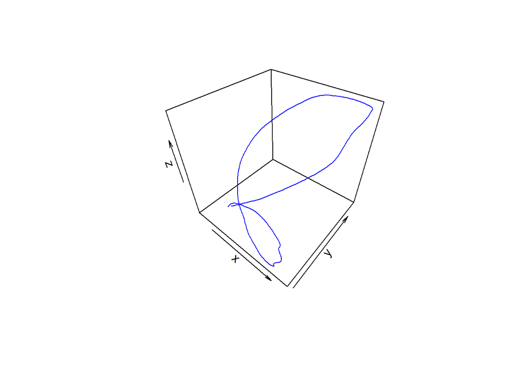

```r
res<-Random.Instance(7)
plot3D::scatter3D(x = res$X,y = res$Y,z = res$Z,col = "blue",type="l",xlab = "x",ylab = "y",zlab = "z")
```

8th Class

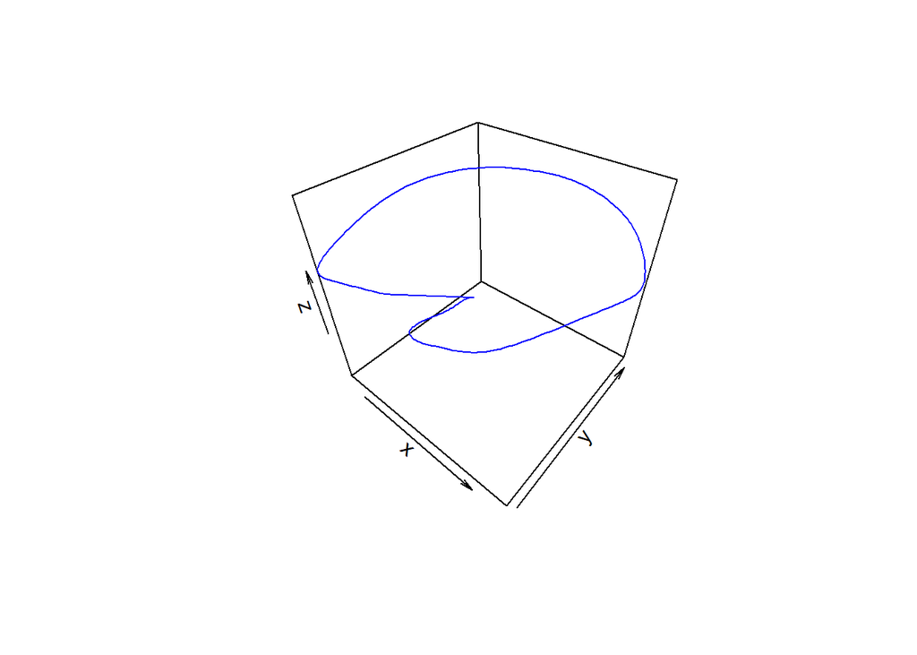

```r
res<-Random.Instance(8)
plot3D::scatter3D(x = res$X,y = res$Y,z = res$Z,col = "blue",type="l",xlab = "x",ylab = "y",zlab = "z")
```

QUESTION PART B

```r
new.X.Train<-X.Train %>% rename(class=V1) %>%
  mutate(time.series.id=row_number()) %>%
  gather(key = "time.index",value = "X",-c(1,ncol(.)))
new.X.Train %>% head
```

```
## # A tibble: 6 x 4
##   class time.series.id time.index        X
##   <dbl>          <int> <chr>         <dbl>
## 1     6              1 V2         -0.304
## 2     5              2 V2          1.63
## 3     5              3 V2          0.661
## 4     3              4 V2          0.00518
## 5     4              5 V2          1.29
## 6     8              6 V2         -0.479
```

```r
new.Y.Train<-Y.Train %>% rename(class=V1) %>%
  mutate(time.series.id=row_number()) %>%
  gather(key = "time.index",value = "Y",-c(1,ncol(.)))

new.Z.Train<-Z.Train %>% rename(class=V1) %>%
  mutate(time.series.id=row_number()) %>%
  gather(key = "time.index",value = "Z",-c(1,ncol(.)))

Long.Data<-full_join(new.X.Train,new.Y.Train,by=c("class","time.series.id","time.index")) %>%
  full_join(new.Z.Train,by=c("class","time.series.id","time.index")) %>% #Join 3 axis together
  separate(time.index,c("V","time.index"),sep = "(?<=V) ?(?=[0-9])") %>% select(-V) %>% #Column names are V2,V3...
  mutate(time.index=as.numeric(time.index)-1) %>% #we remove V and stay with the number
  arrange(time.series.id,class,time.index) %>%
  select(time.series.id,time.index,X,Y,Z,class)

Long.Data %>% head
```

```
## # A tibble: 6 x 6
##   time.series.id time.index      X     Y     Z class
##            <int>      <dbl>  <dbl> <dbl> <dbl> <dbl>
## 1              1          1 -0.304 -2.12 -1.53     6
## 2              1          2 -0.304 -2.12 -1.53     6
## 3              1          3 -0.304 -2.12 -1.53     6
## 4              1          4 -0.304 -2.12 -1.53     6
## 5              1          5 -0.304 -2.12 -1.53     6
## 6              1          6 -0.304 -2.12 -1.53     6
```

```r
Long.Data %>% tail
```

```
## # A tibble: 6 x 6
##   time.series.id time.index     X      Y      Z class
##            <int>      <dbl> <dbl>  <dbl>  <dbl> <dbl>
## 1            896        310  1.77 -0.953 -0.859     5
## 2            896        311  1.97 -0.887 -0.849     5
## 3            896        312  2.03 -0.821 -0.828     5
## 4            896        313  1.99 -0.755 -0.800     5
## 5            896        314  1.89 -0.688 -0.769     5
## 6            896        315  1.79 -0.622 -0.737     5
```

```r
#Apply PCA
pca.data<-Long.Data %>% select(X,Y,Z) %>% as.matrix()
pca.res<-prcomp(pca.data,center = T,scale. = T)$rotation %>% as_tibble()
pca.res
```

```
## # A tibble: 3 x 3
##     PC1     PC2    PC3
##   <dbl>   <dbl>  <dbl>
## 1 0.427 -0.776  -0.464
## 2 0.721 -0.0171  0.692
## 3 0.546  0.630  -0.553
```

```r
#Create PC1 values using PCA weights
PC1<-pca.data%*%pca.res$PC1 %>% as_tibble(.name_repair = "minimal")
colnames(PC1)<-"PC1"

pca.final<-Long.Data %>% select(time.series.id,time.index,class) %>% bind_cols(PC1)
pca.final %>% head
```

```
## # A tibble: 6 x 4
##   time.series.id time.index class   PC1
##            <int>      <dbl> <dbl> <dbl>
## 1              1          1     6 -2.49
## 2              1          2     6 -2.49
## 3              1          3     6 -2.49
## 4              1          4     6 -2.49
## 5              1          5     6 -2.49
## 6              1          6     6 -2.49
```

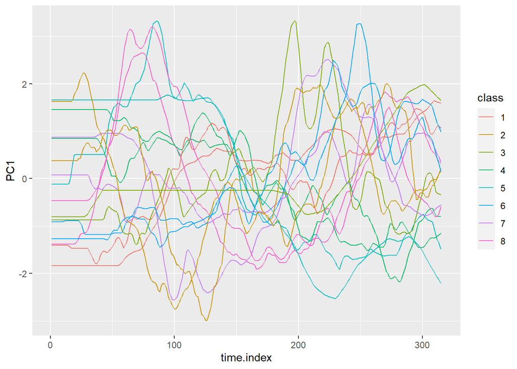

```r
#Randomly select 2 time series from each class
random.sample<-2
pca.test<-pca.final %>% select(class,time.series.id) %>% unique() %>%
  group_by(class) %>%
  mutate(row.no=row_number(),
         maxrow.no=max(row.no)) %>%
  filter(row.no %in% sample(1:maxrow.no[1],random.sample)) %>%
  ungroup()

pca.final %>% filter(time.series.id %in% pca.test$time.series.id) %>%
  mutate(class=as.character(class)) %>%
  ggplot(aes(x=time.index, y=PC1,group=time.series.id, colour=class)) +
  geom_line()
```

This is a bit confusing so we remove time.series.id info. In this way, two samples from each class will create areas.

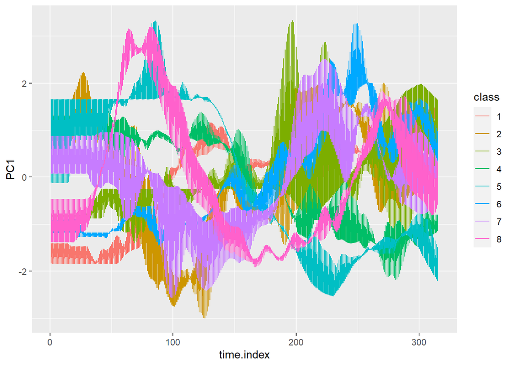

```r
pca.final %>% filter(time.series.id %in% pca.test$time.series.id) %>%
  mutate(class=as.character(class)) %>%
  ggplot(aes(x=time.index, y=PC1, colour=class)) +
  geom_line()
```

With geom_smooth it may be easy to visualize

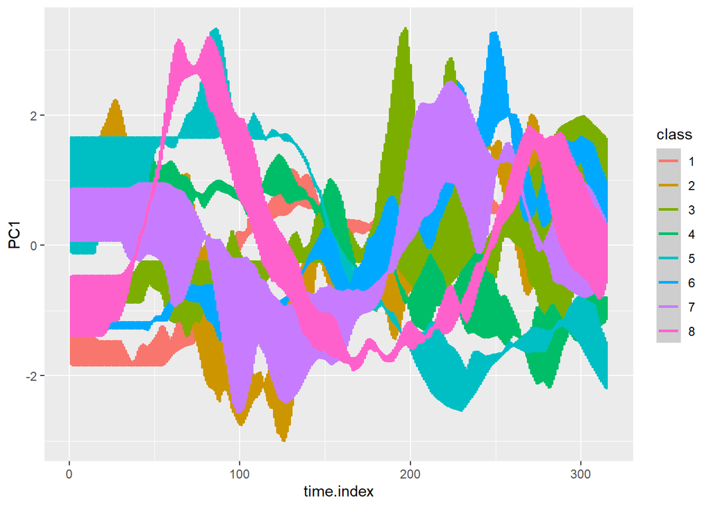

```r
pca.final %>% filter(time.series.id %in% pca.test$time.series.id) %>%
  mutate(class=as.character(class)) %>%
  ggplot(aes(x=time.index, y=PC1, colour=class)) +
  geom_smooth(stat = "identity")
```

We think classes can be separated with PCA as can be seen from the plots. It looks like each of them has unique pattern.

QUESTION PART C

1st Class

```r
pca.tmp<-Long.Data %>% filter(class==1) %>%
  select(X,Y,Z) %>% as.matrix()
pca.res<-prcomp(pca.tmp,center = T,scale.=T)
pca.res$rotation
```

```
##         PC1        PC2        PC3
## X 0.3567943  0.8962945 -0.2633513
## Y 0.6911427 -0.0636012  0.7199143
## Z 0.6285058 -0.4388747 -0.6421600
```

```r
summary(pca.res)
```

```
## Importance of components:
##                           PC1    PC2    PC3
## Standard deviation     1.1780 0.9846 0.8019
## Proportion of Variance 0.4625 0.3231 0.2143
## Cumulative Proportion  0.4625 0.7857 1.0000
```

2nd Class

```r
pca.tmp<-Long.Data %>% filter(class==2) %>%
  select(X,Y,Z) %>% as.matrix()
pca.res<-prcomp(pca.tmp,center = T,scale.=T)
pca.res$rotation
```

```
##          PC1        PC2        PC3
## X -0.4554176 -0.8014690 -0.3876110
## Y -0.6845547  0.0368908  0.7280274
## Z -0.5691921  0.5968974 -0.5654501
```

```r
summary(pca.res)
```

```
## Importance of components:
##                           PC1    PC2    PC3
## Standard deviation     1.2400 0.9683 0.7244
## Proportion of Variance 0.5125 0.3125 0.1749
## Cumulative Proportion  0.5125 0.8251 1.0000
```

3rd Class

```r
pca.tmp<-Long.Data %>% filter(class==3) %>%
  select(X,Y,Z) %>% as.matrix()
pca.res<-prcomp(pca.tmp,center = T,scale.=T)
pca.res$rotation
```

```
##          PC1         PC2        PC3
## X -0.6747233 0.009098704 -0.7380147
## Y -0.5306881 0.688955376  0.4936706
## Z  0.5129510 0.724746648 -0.4600257
```

```r
summary(pca.res)
```

```
## Importance of components:
##                           PC1    PC2    PC3
## Standard deviation     1.2737 0.9475 0.6928
## Proportion of Variance 0.5407 0.2993 0.1600
## Cumulative Proportion  0.5407 0.8400 1.0000
```

4th Class

```r
pca.tmp<-Long.Data %>% filter(class==4) %>%
  select(X,Y,Z) %>% as.matrix()
pca.res<-prcomp(pca.tmp,center = T,scale.=T)
pca.res$rotation
```

```
##          PC1       PC2        PC3
## X -0.6806323 0.1125840 -0.7239230
## Y -0.6342065 0.4041375  0.6591320
## Z  0.3667721 0.9077432 -0.2036675
```

```r
summary(pca.res)
```

```
## Importance of components:
##                           PC1    PC2    PC3
## Standard deviation     1.2847 0.9606 0.6534
## Proportion of Variance 0.5501 0.3076 0.1423
## Cumulative Proportion  0.5501 0.8577 1.0000
```

5th Class

```r
pca.tmp<-Long.Data %>% filter(class==5) %>%
  select(X,Y,Z) %>% as.matrix()
pca.res<-prcomp(pca.tmp,center = T,scale.=T)
pca.res$rotation
```

```
##          PC1        PC2         PC3
## X -0.3988772 -0.9154472  0.05341656
## Y -0.6425900  0.3205950  0.69591444
## Z -0.6541980  0.2432595 -0.71613529
```

```r
summary(pca.res)
```

```
## Importance of components:
##                           PC1    PC2     PC3
## Standard deviation     1.3934 0.9077 0.48425
## Proportion of Variance 0.6472 0.2746 0.07817
## Cumulative Proportion  0.6472 0.9218 1.00000
```

6th Class

```r
pca.tmp<-Long.Data %>% filter(class==6) %>%
  select(X,Y,Z) %>% as.matrix()
pca.res<-prcomp(pca.tmp,center = T,scale.=T)
pca.res$rotation
```

```
##          PC1         PC2        PC3
## X  0.2060269 -0.96424253  0.1667011
## Y -0.6797230 -0.26356876 -0.6844765
## Z -0.7039386 -0.02771001  0.7097201
```

```r
summary(pca.res)
```

```
## Importance of components:
##                           PC1    PC2     PC3
## Standard deviation     1.3098 0.9942 0.54420
## Proportion of Variance 0.5718 0.3295 0.09872
## Cumulative Proportion  0.5718 0.9013 1.00000
```

7th Class

```r
pca.tmp<-Long.Data %>% filter(class==7) %>%
  select(X,Y,Z) %>% as.matrix()
pca.res<-prcomp(pca.tmp,center = T,scale.=T)
pca.res$rotation
```

```
##          PC1         PC2        PC3
## X -0.2290300 -0.92481420 -0.3037498
## Y -0.7150258 -0.05190498  0.6971685
## Z -0.6605175  0.37686147 -0.6493782
```

```r
summary(pca.res)
```

```
## Importance of components:
##                           PC1    PC2    PC3
## Standard deviation     1.2480 1.0144 0.6429
## Proportion of Variance 0.5192 0.3430 0.1378
## Cumulative Proportion  0.5192 0.8622 1.0000
```

8th Class

```r
pca.tmp<-Long.Data %>% filter(class==8) %>%
  select(X,Y,Z) %>% as.matrix()
pca.res<-prcomp(pca.tmp,center = T,scale.=T)
pca.res$rotation
```

```
##         PC1         PC2        PC3
## X 0.5744344 -0.58391123  0.5736487
## Y 0.6927923 -0.02643827 -0.7206524
## Z 0.4359633  0.81138690  0.3893422
```

```r
summary(pca.res)
```

```
## Importance of components:
##                           PC1    PC2     PC3
## Standard deviation     1.3566 0.9676 0.47278
## Proportion of Variance 0.6134 0.3121 0.07451
## Cumulative Proportion  0.6134 0.9255 1.00000
```

QUESTION PART D

```r
X.Train.dist<-as.matrix(X.Train[,-1])
Y.Train.dist<-as.matrix(Y.Train[,-1])
Z.Train.dist<-as.matrix(Z.Train[,-1])
classes<-X.Train[,1]
colnames(classes)<-"class"

colnames(X.Train.dist)<-paste0("V",1:ncol(X.Train.dist))
colnames(Y.Train.dist)<-paste0("V",1:ncol(Y.Train.dist))
colnames(Z.Train.dist)<-paste0("V",1:ncol(Z.Train.dist))

#Calculate distances between time series (rows)
dist.X<-dist(x=X.Train.dist,method = "euclidean",diag = T,upper = T) %>% as.matrix()
dist.Y<-dist(x=Y.Train.dist,method = "euclidean",diag = T,upper = T) %>% as.matrix()
dist.Z<-dist(x=Z.Train.dist,method = "euclidean",diag = T,upper = T) %>% as.matrix()

dist.all<-dist.X+dist.Y+dist.Z #Sum them up

#Multidimensional scaling to represent on 2d space
Scaled2d<-cmdscale(dist.all,k = 2) %>% as_tibble(.name_repair="minimal")
colnames(Scaled2d)<-c("X","Y")
Scaled2d %>% head()
```

```
## # A tibble: 6 x 2
##       X      Y
##   <dbl>  <dbl>
## 1  27.0  26.3
## 2 -48.5  -7.08
## 3 -39.3  27.2
## 4 -14.1 -24.2
## 5 -17.9  18.5
## 6 -21.8  12.2
```

Visualization

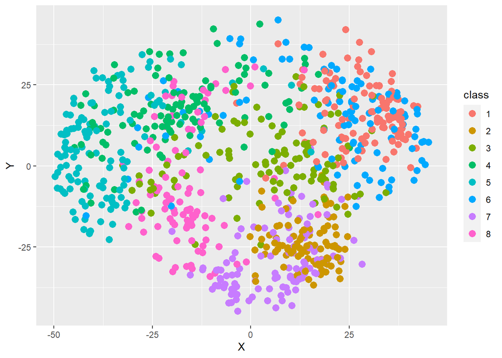

```r
Scaled2d %>%
  bind_cols(classes) %>%
  mutate(class=as.character(class)) %>%
  ggplot(aes(x=X,y=Y,colour=class))+
  geom_point(size=3)
```

As can be seen from the plot, classes are grouped together meaning that samples within classes are close. In other words, multidimensional scaling works for separating classes.